# Bootstrap analysis: Determine Top Performers - Task2

Sage CNB Team

2025-11-13

## Introduction & Goal 🎯

This notebook outlines the methodology for declaring top-performing methods in the [SEA-AD DREAM Challenge](https://www.synapse.org/sea_ad_dream), specifically by assessing for “tied” performance between submissions.

### Task 2 Evaluation Overview

The primary metric used to evaluate submissions for Task 2 is the Concordance Correlation Coefficient (`CCC`), computed on the predicted percentages of 6e10 and AT8 positive areas. For final ranking, we will take the average CCC across both areas.

### Methodology

To determine if methods are substantially different in performance, we employ a bootstrapping approach combined with a Bayes Factor ($\text{BF}$) calculation. This statistical framework allows us to assess the statistical equivalence of models across many resampled datasets.

1. **Bootstrapping:** repeatedly sample with replacement (e.g. 1,000 - 10,000 times) the submitted predictions and the groundtruth values. This generates a distribution of performance scores for each participant under various data scenarios.
2. **Bayes Factor (BF):** calculate the BF for each method relative to the top- performing reference method. The BF quantifies the evidence of one model being better than another.

### Determining the Top-Performer(s)

A smaller BF indicates more similar performance. We use a BF cut-off of 3 to define a tie. Any method with a $\text{BF} \le 3$ (relative to the best method) is considered not substantially different and is therefore declared a top-performer alongside the reference method.

## Setup and Data Loading 🛠

### Packages

```r
suppressPackageStartupMessages(library(ggplot2))
suppressPackageStartupMessages(library(dplyr))
suppressPackageStartupMessages(library(knitr))
suppressPackageStartupMessages(library(synapser))

# Login to Synapse.
syn$login(silent=TRUE)
```

### Helper Functions

In addition to importing the scoring functions provided by the challenge organizers, we also define two functions for data processing and analysis:

1. `get_name()`: this function resolves a Synapse `submitterid` (which can be a userID or teamID) into a human-readable username or team name. This will later help with plotting.
2. `computeBayesFactor()`: this function is an updated implementation of the BF calculation, superseding the outdated version in the `challengescoring` package. It calculates the BF for all submissions relative to a specified reference prediction index (`refPredIndex`).

```r
reticulate::source_python("../evaluation/dream_evaluation.py")

get_name <- function(id) {
  name <- tryCatch({
    syn$getUserProfile(id)$userName
  }, error = function(err) {
    syn$getTeam(id)$name
  })
  name
}

computeBayesFactor <- function(bootstrapMetricMatrix,
                               refPredIndex,
                               invertBayes) {
  M <- as.data.frame(bootstrapMetricMatrix - bootstrapMetricMatrix[,refPredIndex])
  K <- apply(M ,2, function(x) {
    k <- sum(x >= 0)/sum(x < 0)

    # Logic handles whether reference column is the best set of predictions.
    if(sum(x >= 0) > sum(x < 0)){
      return(k)
    }else{
      return(1/k)
    }
  })
  K[refPredIndex] <- 0
  if(invertBayes == T){K <- 1/K}
  return(K)
}
```

### Data Acquisition

The Final Round prediction files and the corresponding groundtruth file are retrieved from Synapse, where they are currently stored.

Task 2 Final Round Leaderboard (as seen on Synapse)

| id | submitterid | 6e10_AT8_Average_CCC |
| --- | --- | --- |
| 9761305 | CMC-TJU | 0.4763385 |
| 9761321 | gisl7 | 0.4356768 |
| 9761297 | BioICAR | 0.3756077 |
| 9761090 | Metformin-121 | 0.3475705 |
| 9760855 | nkck | 0.3333725 |
| 9761236 | christina.hshi | 0.3054123 |
| 9761139 | TeamGeckoAD | 0.2861303 |
| 9761292 | Mount_Sinai_Team | 0.2736089 |
| 9761233 | TREATS | 0.2630888 |
| 9761251 | danielr | 0.1053188 |

## Bootstrapping Procedure 📊

First, we combine all individual submission predictions and the groundtruth values into a single data frame. This single source will help create a more efficient resampling process for the bootstrapping analysis.

Preview of Model Predictions and Corresponding Groundtruth Values

| donor_id | CMC-TJU_predicted_6e10 | CMC-TJU_predicted_at8 | gisl7_predicted_6e10 | gisl7_predicted_at8 | BioICAR_predicted_6e10 | BioICAR_predicted_at8 | Metformin-121_predicted_6e10 | Metformin-121_predicted_at8 | nkck_predicted_6e10 | nkck_predicted_at8 | christina.hshi_predicted_6e10 | christina.hshi_predicted_at8 | TeamGeckoAD_predicted_6e10 | TeamGeckoAD_predicted_at8 | Mount_Sinai_Team_predicted_6e10 | Mount_Sinai_Team_predicted_at8 | TREATS_predicted_6e10 | TREATS_predicted_at8 | danielr_predicted_6e10 | danielr_predicted_at8 | truth_6e10 | truth_at8 |
| --- | --- | --- | --- | --- | --- | --- | --- | --- | --- | --- | --- | --- | --- | --- | --- | --- | --- | --- | --- | --- | --- | --- |
| D063 | 1.681756 | 0.1962573 | 0.5934855 | 0.0921971 | 2.8145721 | 1.608247 | 2.440950 | 0.9204269 | 0.0340406 | 0.0570407 | 1.629144 | 0.3157195 | 1.2780492 | 0.8973691 | 0.000000 | 0.2480710 | 2.381340 | 0.000000 | 3.0644452 | 1.5380933 | 0.443392 | 0.166383 |
| D082 | 2.381380 | 2.6000117 | 5.3990951 | 1.1307690 | 2.2027899 | 1.314471 | 2.817942 | 2.0036156 | 3.1957307 | 2.9272592 | 3.628094 | 2.4488726 | 2.1524610 | 2.3734606 | 3.481744 | 3.2017656 | 2.367567 | 1.561111 | 1.3687973 | 1.0673220 | 2.895230 | 3.117064 |
| D085 | 1.389954 | 0.2528247 | 0.7122468 | 0.1464643 | 1.5499403 | 0.305857 | 2.745873 | 1.0310358 | 2.7036347 | 1.4278576 | 3.346273 | 1.5989419 | 1.7816298 | 1.5620893 | 2.029596 | 0.3290705 | 2.398048 | 0.000000 | 0.8673458 | 0.0712004 | 0.000000 | 0.054521 |
| D091 | 3.611240 | 2.0570419 | 6.3924982 | 4.1702110 | 3.5771638 | 2.476196 | 2.958351 | 2.8405817 | 2.2115388 | 3.4272590 | 7.514204 | 1.9614855 | 0.9016954 | 3.5349959 | 3.678980 | 2.8391599 | 2.211574 | 1.998940 | 0.9592713 | 0.1930797 | 0.395063 | 5.352888 |
| D124 | 1.174042 | 0.4868843 | 2.3722091 | 0.2406317 | 0.4730794 | 1.259840 | 1.008831 | 0.3520681 | 0.0046083 | 0.1874695 | 1.458579 | 0.2473863 | 1.7077052 | 1.0697641 | 1.560808 | 1.1086650 | 0.000000 | 0.000000 | 2.0106442 | 0.8577510 | 0.340269 | 0.103771 |
| D164 | 11.049219 | 1.8835133 | 11.6337020 | 4.2473956 | 7.4750108 | 1.974882 | 6.756293 | 1.1706963 | 2.2115388 | 2.4272628 | 10.390841 | 1.6415989 | 3.0619978 | 2.6524951 | 10.007266 | 2.3498135 | 3.796323 | 1.692103 | 1.0262731 | 0.0895485 | 5.452740 | 2.637034 |

Next, we perform a pre-bootstrapping verification to ensure the bootstrapping logic correctly reproduces the published Final Round scores *prior* to any resampling. This serves as a critical check on the bootstrapping and scoring functions.

```r
bs.check <- sapply(names(pred_filenames), function(team) {
  team_6e10_name <- paste0(team, "_predicted_6e10")
  team_at8_name <- paste0(team, "_predicted_at8")

  apply(matrix(1:nrow(truth), nrow(truth), 1), 2, function(ind) {
    # Calculate CCC for 6e10 area first
    ccc.6e10 <- concordance_correlation_coefficient(
      submissions$truth_6e10[ind],
      submissions[[team_6e10_name]][ind]
    )
    # Calculate CCC for AT8 area next
    ccc.at8 <- concordance_correlation_coefficient(
      submissions$truth_at8[ind],
      submissions[[team_at8_name]][ind]
    )
    # Return average of the two areas
    (ccc.6e10 + ccc.at8) / 2
  })
})
```

Comparison of “Bootstrapped” Average Scores (Prior to Resampling) and Original Average Scores

| submitterid | bf_calculated_average | original_average | scores_match |
| --- | --- | --- | --- |
| CMC-TJU | 0.4763385 | 0.4763385 | TRUE |
| gisl7 | 0.4356768 | 0.4356768 | TRUE |
| BioICAR | 0.3756077 | 0.3756077 | TRUE |
| Metformin-121 | 0.3475705 | 0.3475705 | TRUE |
| nkck | 0.3333725 | 0.3333725 | TRUE |
| christina.hshi | 0.3054123 | 0.3054123 | TRUE |
| TeamGeckoAD | 0.2861303 | 0.2861303 | TRUE |
| Mount_Sinai_Team | 0.2736089 | 0.2736089 | TRUE |
| TREATS | 0.2630888 | 0.2630888 | TRUE |
| danielr | 0.1053188 | 0.1053188 | TRUE |

The core bootstrapping process is then executed:

- Resample the rows (data points) of the combined dataframe 10,000 times ($N=10,000$) with replacement
- For each of the $N$ bootstrap samples, we re-score every submission using the primary challenge metric (Concordance Correlation Coefficient, `CCC`) in the two target areas: 6e10 and AT8
- The final result for each submission on that sample will be the average CCC across the two areas

This will produce a matrix of 10,000 bootstrapped average scores per submission.

```r
# Set seed for reproducible results (since we're doing a random sample)
set.seed(202511)

# Run bootstrapping.
N <- 10000
bs_indices <- matrix(1:nrow(truth), nrow(truth), N) %>%
  apply(2, sample, replace = TRUE)

bs <- sapply(names(pred_filenames), function(team) {
  team_6e10_name <- paste0(team, "_predicted_6e10")
  team_at8_name <- paste0(team, "_predicted_at8")

  apply(bs_indices, 2, function(ind) {
    ccc.6e10 <- concordance_correlation_coefficient(
      submissions$truth_6e10[ind],
      submissions[[team_6e10_name]][ind]
    )
    ccc.at8 <- concordance_correlation_coefficient(
      submissions$truth_at8[ind],
      submissions[[team_at8_name]][ind]
    )
    (ccc.6e10 + ccc.at8) / 2
  })
})
```

## Bayes Factor Calculation 📈

The resulting $10,000 \times \text{number of submissions}$ matrix of bootstrapped scores is used to calculate the Bayes Factor (BF) for each submission.

The top-performing model (highest average score of `6e10_CCC` and `AT8_CCC`) is automatically set as the reference prediction ($BF=0$) against which all other methods are compared.

As established earlier, a Bayes factor $\le 3$ indicates that a method’s performance is not substantially different from the top performer.

| submission | bayes |
| --- | --- |
| CMC-TJU | 0.000000 |
| gisl7 | 3.837929 |
| BioICAR | 399.000000 |
| Metformin-121 | 383.615385 |
| nkck | 25.315790 |
| christina.hshi | Inf |
| TeamGeckoAD | 1427.571429 |
| Mount_Sinai_Team | 587.235294 |
| TREATS | Inf |
| danielr | Inf |

## Results & Top Performer Determination 🏆

Methods falling into the “BF $\le 3$” category, including the top performer ($BF=0$), will be declared “Top Performers” for this challenge task.

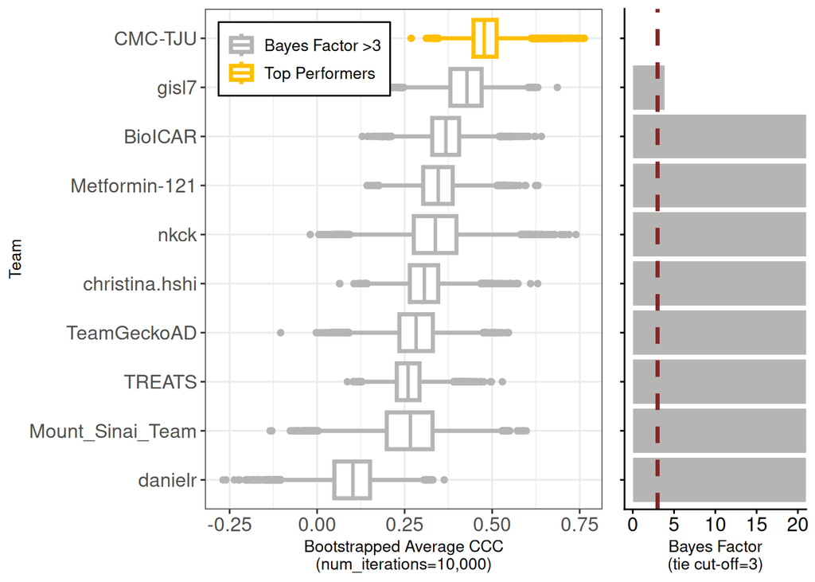

## Conclusion ✨

The objective of this analysis was to use the Bayes factor to identify submissions that are statistically indistinguishable from the overall top performer, using a threshold of $\text{BF} \le 3$ to define a tie.

The analysis confirms that the reference submission, team CMC-TJU ($\text{BF}=0$), is the only team whose performance is not substantially different from itself. Since no other submissions yielded a Bayes factor $\le 3$, **team CMC-TJU is declared the sole “Top Performer” for Task 2 of the SEA-AD DREAM Challenge**.